# GroupDReport

## tag66, what was on the menu

`tag66` represents what was on the menu that day, scraped from the school’s [website](https://www.amherst.edu/campuslife/housing-dining/dining/menu), the details of this will be explained in the next section. As there are 55 categories, and each is a long string, the labels of these are omitted in the following plot which is displayed to show the variance in count between menu types. In light of this variance, we used `tag66` in our model.

- It’s worth noting that the count of each these varied significantly, and the most common meal type was ‘free cage’ because this represented every breakfast and a few brunches (790 vs 612), and that fortunately burger was the second most common mean type because as we later found out, this meal had quite a strong positive effect on `count`.

```
##             . Freq
## 1   free cage  789
## 2   hot burge   69
## 3   roasted s   58
## 4   roasted o   50
## 5   sausage p   47
## 6   rice; gre   46
## 7   tortilla;   45
## 8   wrap; chi   38
## 9   steamed r   33
## 10  bbq pork    25
## 11  grilled a   25
## 12  sauce; ch   25
## 13  and sauce   24
## 14  cantina b   24
```

[output cut: 41 more lines]

```
## .
## Breakfast    Dinner     Lunch
##       611       653       658
```

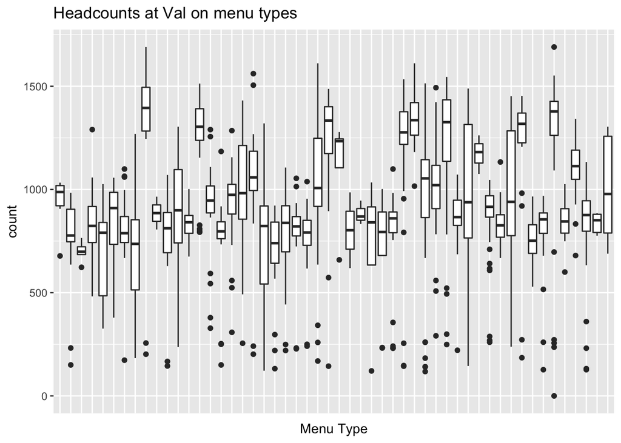

## Semester*Weekday, the interaction between them

During our analysis we found a relatively significant interaction between `semester` and `weekday`, this is indicated by the relative absence of parallel slopes in this interaction plot where we notice Spring turnout to be consistently lower than Fall (perhaps due to study abroad?):

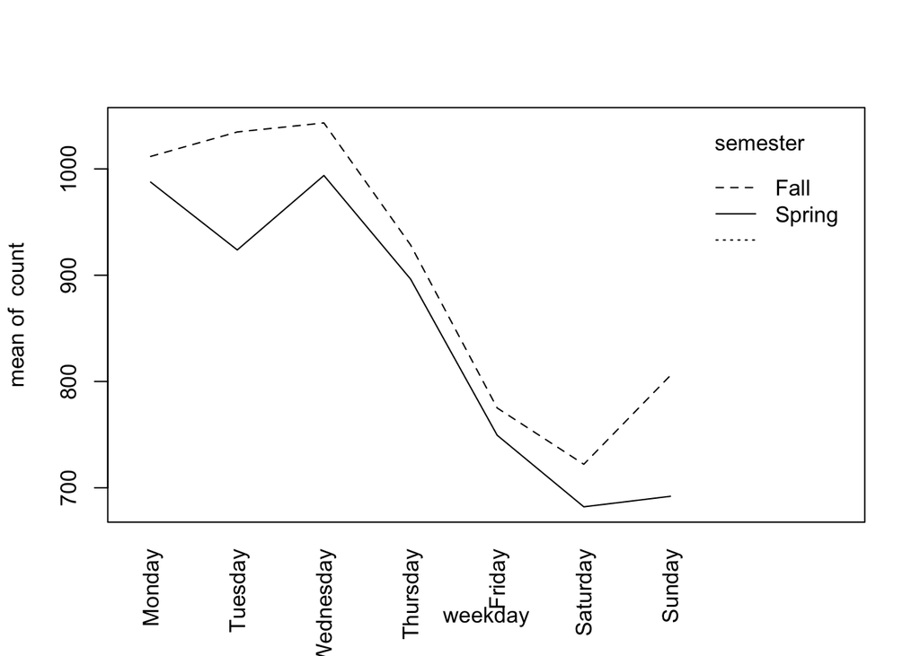